# Statistics_analysis

Mikayla, Mustafa, Yibo

2023-05-08

# Data structure:

We have the following variables in the data:

# Preprocessing

## Preprocess CNV data as the data was in matrix format

```r
# Load required libraries
library(tidyverse)
# Read the input CSV file
input_data <- read_csv("CNV_variance_all_cells.csv")
# Convert input_data to a data frame if it's not
input_data <- as.data.frame(input_data)

# Extract Patient_ID and tumor_GIS_variance values
patient_id <- input_data$patient_id
tumor_gis_variance <- diag(as.matrix(input_data[,-1]))

# Combine the extracted data into a new data frame
output_data <- tibble(Patient_ID = patient_id, tumor_GIS_variance = tumor_gis_variance)

# Write the output CSV file
write_csv(output_data, "CNV_tumor_all.csv")
```

```r
# Load required libraries
library(tidyverse)

# Read the input CSV file
input_data <- read_csv("CNV_variance.csv")
# Convert input_data to a data frame if it's not
input_data <- as.data.frame(input_data)

# Extract Patient_ID and tumor_GIS_variance values
patient_id <- input_data$patient_id
tumor_gis_variance <- diag(as.matrix(input_data[,-1]))

# Combine the extracted data into a new data frame
output_data <- tibble(Patient_ID = patient_id, tumor_GIS_variance = tumor_gis_variance)

# Write the output CSV file
write_csv(output_data, "CNV_tumor.csv")
```

## Merge the preprocessed CNV variance files with the metadata

```r
# Load required libraries
library(tidyverse)

# Read the CSV files
gse_metadata <- read_csv("GSE_metadata.csv")
cnv_tumor <- read_csv("CNV_tumor.csv")
cnv_all <- read_csv("CNV_all.csv")
# Merge the data based on the shared column Patient_ID
merged_data <- gse_metadata %>%
  left_join(cnv_tumor, by = "Patient_ID") %>%
  left_join(cnv_all, by = "Patient_ID")

# Write the merged data to a new CSV file
write_csv(merged_data, "merged_data.csv")
```

## Merge the GMA and scSUbtype entropy, GSI, and CV to three different csv file for further analysis.

```r
# Read the CSV files
merged_data <- read_csv("merged_data.csv")
gene_module_ok <- read_csv("gene_module_ok.csv")
gene_module_k7 <- read_csv("gene_module_k7.csv")
scSubtype = read_csv("scSubtype.csv")
# Merge Gini_Simpson and rename columns
merged_GS <- gene_module_ok %>%
  select(Patient_ID, GMA_tumors_GS = Gini_Simpson) %>%
  left_join(gene_module_k7 %>% select(Patient_ID, GMA_all_cells_GS = Gini_Simpson), by = "Patient_ID") %>%
  left_join(merged_data, by = "Patient_ID") %>%
  left_join(scSubtype %>% select(Patient_ID, scSubtype_GS = Gini_Simpson))
# Write merged_GS to a new CSV file
write_csv(merged_GS, "merged_GS.csv")

# Merge Entropy and rename columns
merged_Entropy <- gene_module_ok %>%
  select(Patient_ID, GMA_tumors_Entropy = Entropy) %>%
  left_join(gene_module_k7 %>% select(Patient_ID, GMA_all_cells_Entropy = Entropy), by = "Patient_ID") %>%
  left_join(merged_data, by = "Patient_ID") %>%
  left_join(scSubtype %>% select(Patient_ID, scSubtype_Entropy = Entropy))
# Write merged_Entropy to a new CSV file
write_csv(merged_Entropy, "merged_Entropy.csv")

# Merge CV, rename columns, and merge with merged_data
merged_CV <- gene_module_ok %>%
  select(Patient_ID, GMA_tumors_CV = CV) %>%
  left_join(gene_module_k7 %>% select(Patient_ID, GMA_all_cells_CV = CV), by = "Patient_ID") %>%
  left_join(merged_data, by = "Patient_ID") %>%
  left_join(scSubtype %>% select(Patient_ID, scSubtype_CV = CV))
# Write merged_CV to a new CSV file
write_csv(merged_CV, "merged_CV.csv")
```

# Descriptive statistics

```r
# Read the merged CSV files
merged_GS <- read_csv("merged_GS.csv")
merged_Entropy <- read_csv("merged_Entropy.csv")
merged_CV <- read_csv("merged_CV.csv")
# Merge the data based on the shared column Patient_ID
merged_metadata <- merged_GS %>%
  left_join(merged_Entropy, by = "Patient_ID") %>%
  left_join(merged_CV, by = "Patient_ID")

# Write the merged data to a new CSV file
write_csv(merged_metadata, "merged_metadata.csv")
```

## Visualize Distribution

```r
# Read the merged_metadata CSV file
merged_metadata <- read_csv("merged_metadata.csv")
```

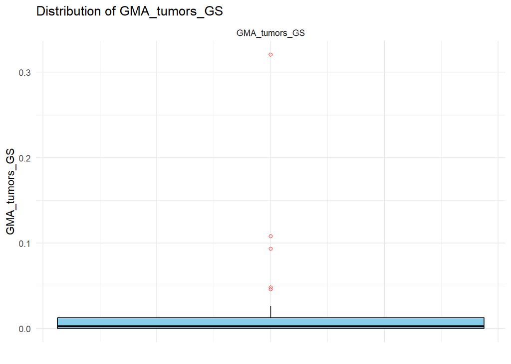

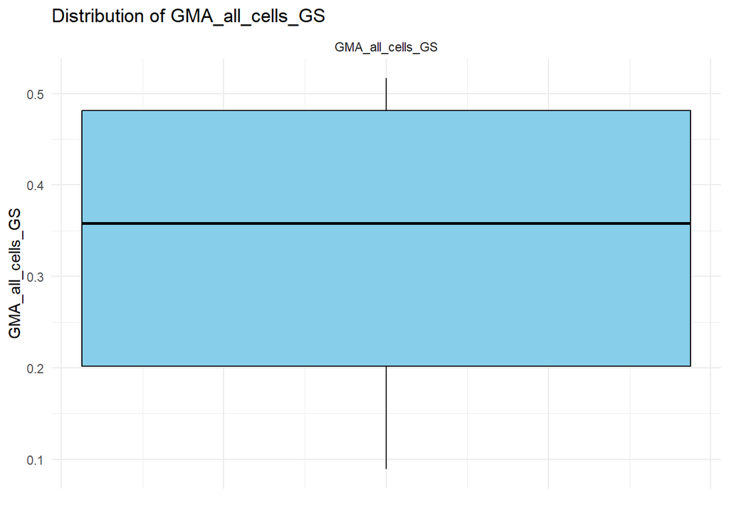

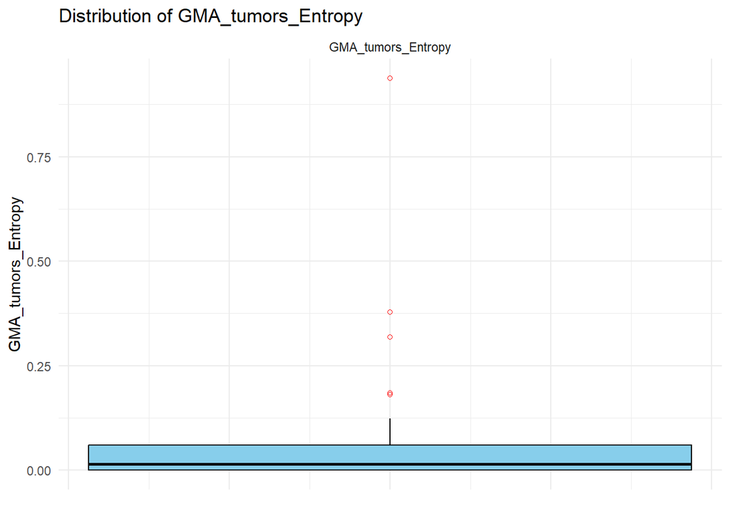

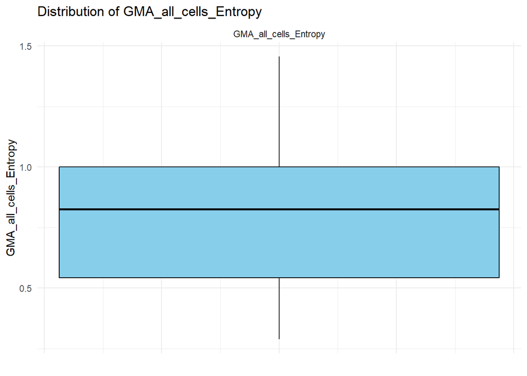

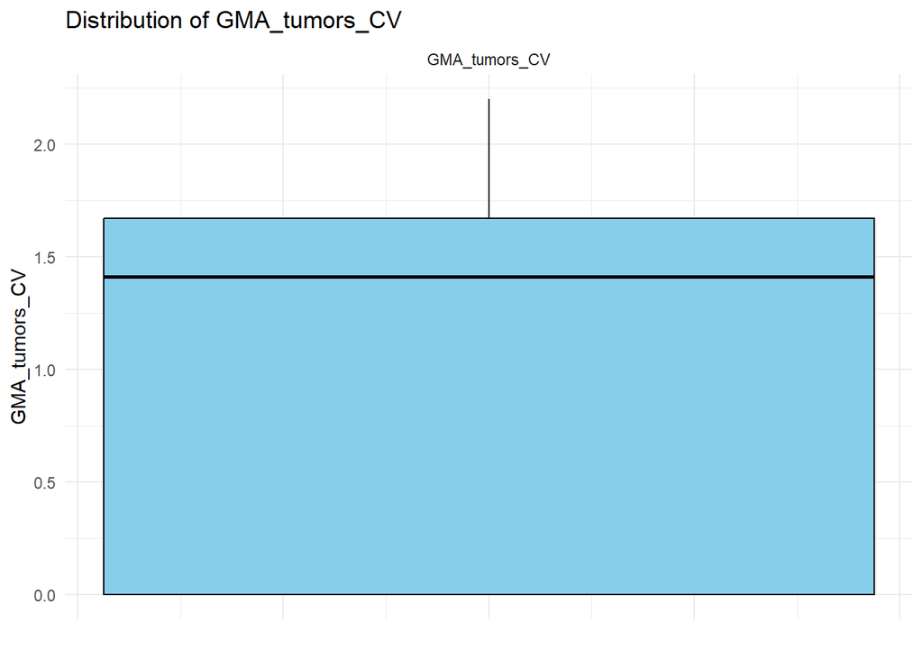

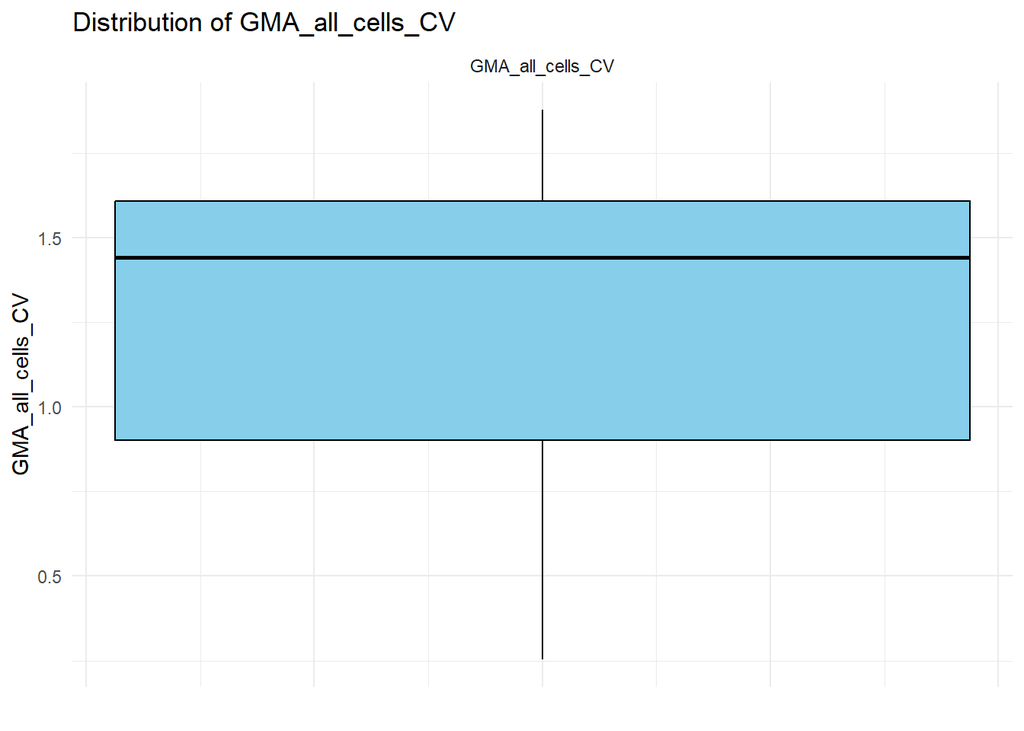

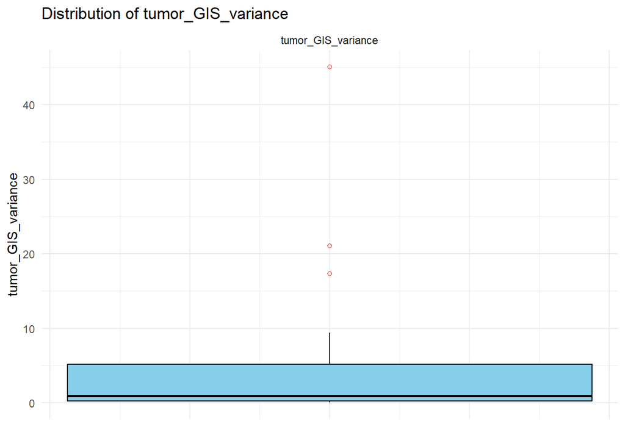

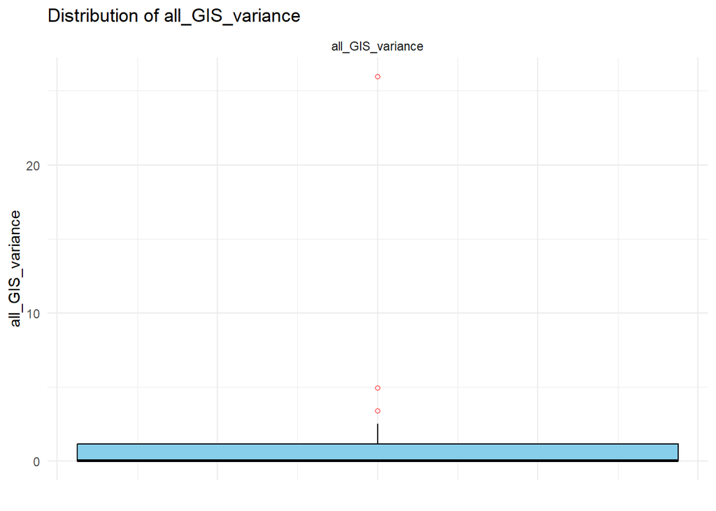

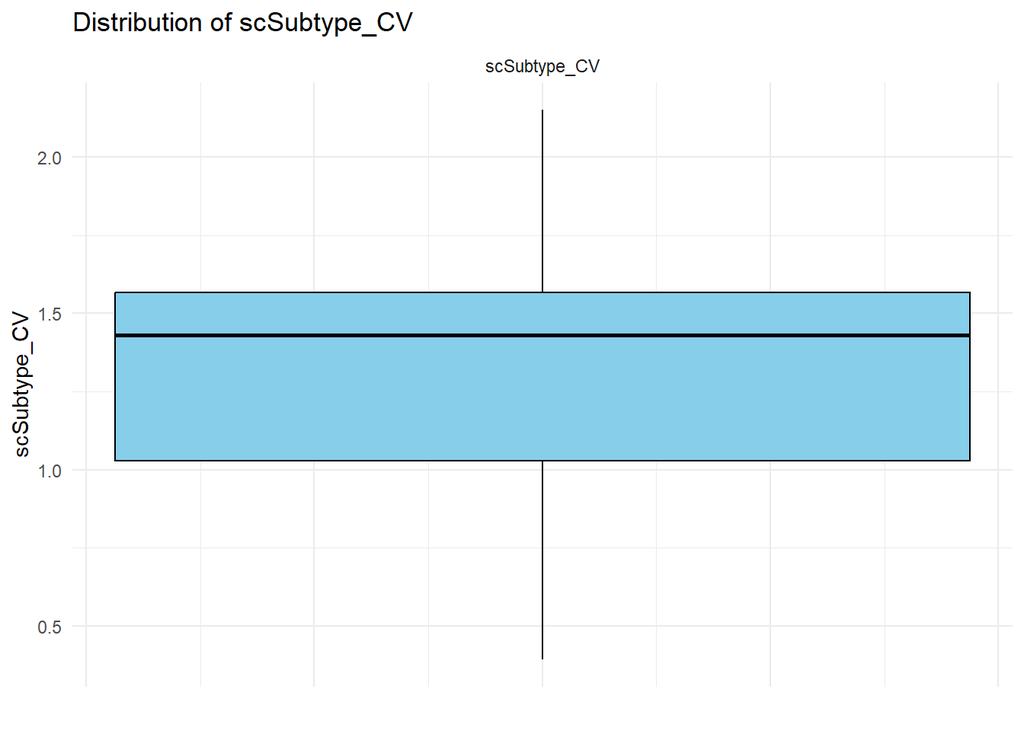

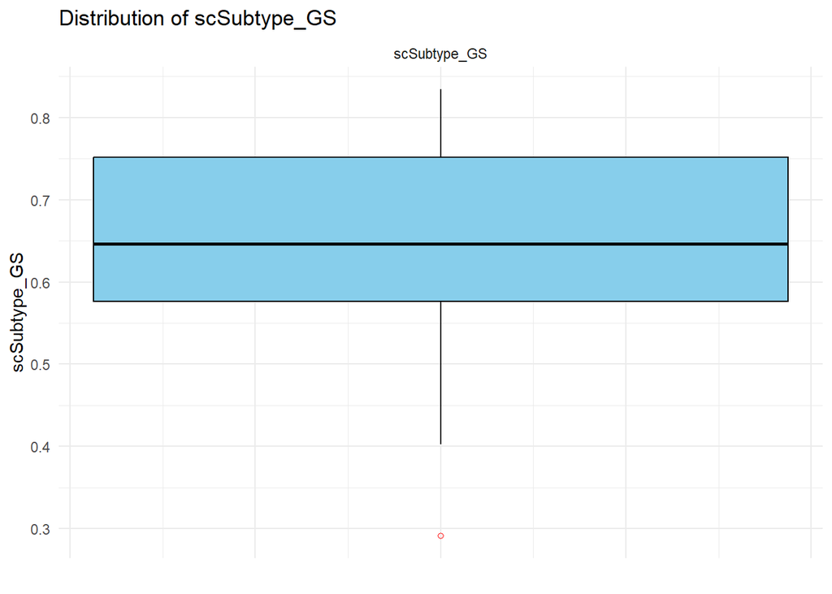

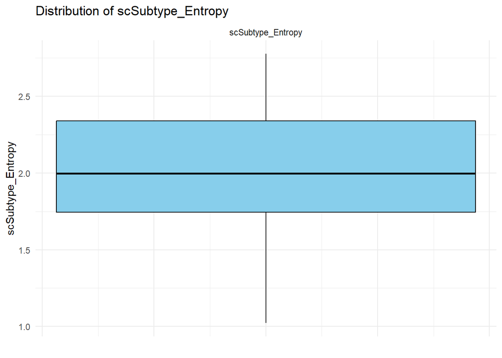

```r
# Continuous and categorical column names
continuous_columns <- c("GMA_tumors_GS", "GMA_all_cells_GS", "GMA_tumors_Entropy",
                        "GMA_all_cells_Entropy", "GMA_tumors_CV", "GMA_all_cells_CV",
                        "tumor_GIS_variance", "all_GIS_variance", "scSubtype_CV", "scSubtype_GS", "scSubtype_Entropy")
categorical_columns <- c("Clinical_Subtype", "Gender")

# Create box plots for continuous columns
continuous_plots <- list()

for (i in seq_along(continuous_columns)) {
  plot <- ggplot(merged_metadata, aes_string(x = 1, y = continuous_columns[i])) +
    geom_boxplot(fill = "skyblue", color = "black", outlier.color = "red", outlier.shape = 1) +
    theme_minimal() +
    theme(axis.text.x = element_blank(),
          axis.ticks.x = element_blank()) +
    ggtitle(paste("Distribution of", continuous_columns[i])) +
    xlab("") +
    ylab(continuous_columns[i]) +
    facet_wrap(~continuous_columns[i], scales = "free_y")
  print(plot)
}
```

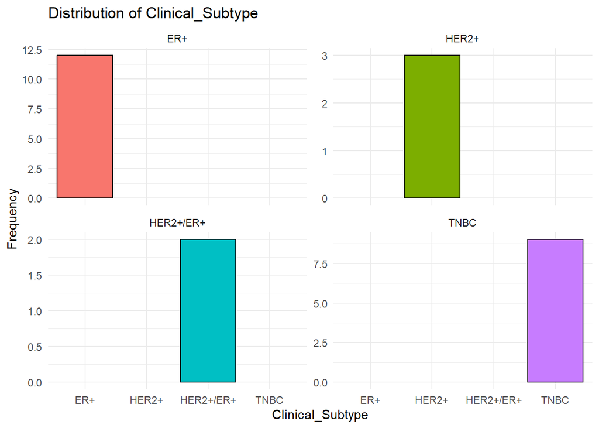

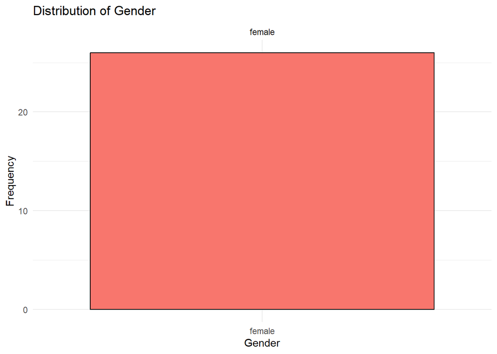

```r
# Create bar plots for categorical columns using facetting
categorical_plots <- list()

for (i in seq_along(categorical_columns)) {
  plot <- ggplot(merged_metadata) +
    geom_bar(aes_string(x = categorical_columns[i], fill = categorical_columns[i]), color = "black") +
    theme_minimal() +
    facet_wrap(facets = vars(eval(parse(text = categorical_columns[i]))), scales = "free_y") +
    labs(title = paste("Distribution of", categorical_columns[i]),
         x = categorical_columns[i],
         y = "Frequency") +
    guides(fill = "none")
  print(plot)
}
```

From the plot above, we can find that when measure heterogeneity based on Gini-Simpson Index and Entropy, tumor cells are more concentrically distributed and has a lower value than that of all cells. However, when measure heterogeneity based on CV, it seems that tumor cells are more sparsely distributed and have a lower value.

While for the variance on genome instability score, it seems that the variance of all cells is much more concentrated and lower than that of tumor cells.

## Correlation analysis

Use pearson correlation for continuous variables:

```r
# Calculate Pearson correlation for continuous variables
continuous_corr <- cor(merged_metadata[continuous_columns], method = "pearson")
continuous_corr
```

```
##                       GMA_tumors_GS GMA_all_cells_GS GMA_tumors_Entropy
## GMA_tumors_GS            1.00000000       0.14230234         0.99581634
## GMA_all_cells_GS         0.14230234       1.00000000         0.11101280
## GMA_tumors_Entropy       0.99581634       0.11101280         1.00000000
## GMA_all_cells_Entropy    0.41437918       0.93993056         0.39106165
## GMA_tumors_CV            0.28146872       0.05974586         0.33403210
## GMA_all_cells_CV         0.30377179      -0.65778187         0.33088297
## tumor_GIS_variance      -0.07390034       0.30847917        -0.09206613
## all_GIS_variance        -0.11001403       0.26560603        -0.12136792
## scSubtype_CV            -0.30201130      -0.29707259        -0.30217912
## scSubtype_GS             0.26943325       0.35444874         0.26679253
## scSubtype_Entropy        0.34165561       0.34467553         0.34094113
##                       GMA_all_cells_Entropy GMA_tumors_CV GMA_all_cells_CV
## GMA_tumors_GS                     0.4143792    0.28146872      0.303771790
## GMA_all_cells_GS                  0.9399306    0.05974586     -0.657781868
## GMA_tumors_Entropy                0.3910617    0.33403210      0.330882970
## GMA_all_cells_Entropy             1.0000000    0.16515784     -0.429701021
## GMA_tumors_CV                     0.1651578    1.00000000      0.279339220
## GMA_all_cells_CV                 -0.4297010    0.27933922      1.000000000
## tumor_GIS_variance                0.2037680   -0.29415851     -0.447363659
## all_GIS_variance                  0.1677702    0.06339073     -0.130577618
## scSubtype_CV                     -0.4403620   -0.02514757      0.004593369
## scSubtype_GS                      0.4728148    0.13897298     -0.033739080
## scSubtype_Entropy                 0.4818681    0.23671556      0.004350345
##                       tumor_GIS_variance all_GIS_variance scSubtype_CV
## GMA_tumors_GS                -0.07390034      -0.11001403 -0.302011300
## GMA_all_cells_GS              0.30847917       0.26560603 -0.297072594
## GMA_tumors_Entropy           -0.09206613      -0.12136792 -0.302179116
## GMA_all_cells_Entropy         0.20376796       0.16777019 -0.440361965
## GMA_tumors_CV                -0.29415851       0.06339073 -0.025147574
## GMA_all_cells_CV             -0.44736366      -0.13057762  0.004593369
## tumor_GIS_variance            1.00000000       0.32476757  0.141264634
## all_GIS_variance              0.32476757       1.00000000  0.059280890
## scSubtype_CV                  0.14126463       0.05928089  1.000000000
## scSubtype_GS                 -0.19772128       0.08434207 -0.911300640
## scSubtype_Entropy            -0.23764894       0.12854150 -0.836958215
##                       scSubtype_GS scSubtype_Entropy
## GMA_tumors_GS           0.26943325       0.341655612
## GMA_all_cells_GS        0.35444874       0.344675532
## GMA_tumors_Entropy      0.26679253       0.340941128
## GMA_all_cells_Entropy   0.47281481       0.481868096
## GMA_tumors_CV           0.13897298       0.236715555
## GMA_all_cells_CV       -0.03373908       0.004350345
## tumor_GIS_variance     -0.19772128      -0.237648939
## all_GIS_variance        0.08434207       0.128541501
## scSubtype_CV           -0.91130064      -0.836958215
## scSubtype_GS            1.00000000       0.966879855
## scSubtype_Entropy       0.96687985       1.000000000
```

## Visualize correlation as heatmap

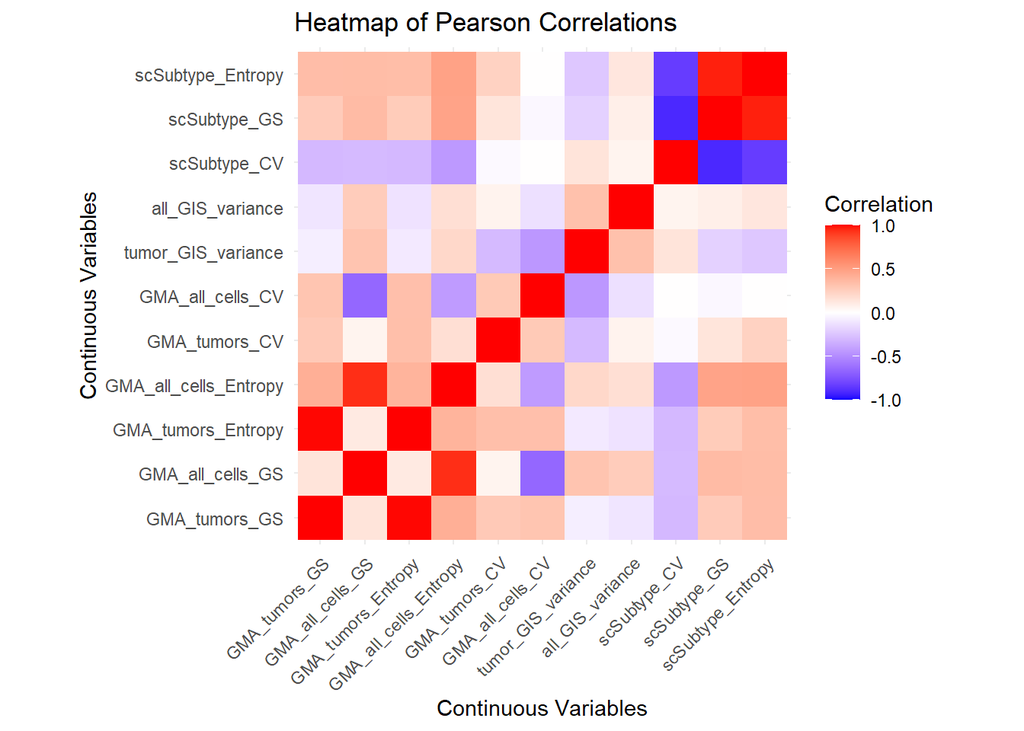

```r
# Load required libraries
library(ggplot2)
library(reshape2)
# Create a heatmap for continuous-continuous correlations
continuous_corr_melted <- melt(continuous_corr)
colnames(continuous_corr_melted) <- c("Variable1", "Variable2", "value")

heatmap <- ggplot(continuous_corr_melted, aes(x = Variable1, y = Variable2, fill = value)) +
  geom_tile() +
  scale_fill_gradient2(low = "blue", high = "red", mid = "white", midpoint = 0, limit = c(-1, 1), name = "Correlation") +
  theme_minimal() +
  theme(axis.text.x = element_text(angle = 45, vjust = 1, hjust = 1)) +
  coord_equal() +
  ggtitle("Heatmap of Pearson Correlations") +
  xlab("Continuous Variables") +
  ylab("Continuous Variables")
print(heatmap)
```

The correlation is as we expected before as GMA for tumors and all cells has certain degree of correlation. Tumor and all cell’s genome instability score variance also has correlation.

GMA_tumors_Entropy has large correlation with GMA_tumor_GS as they are measuring the same heterogeneity. Same applied for GMA_all_cells_GS and GMA_all_cells_Entropy. It seems that the three metrics have great correlation especially for GS and Entropy, while other variables don’t have huge correlation.

## Visualize the relation between each variable and the response variable.

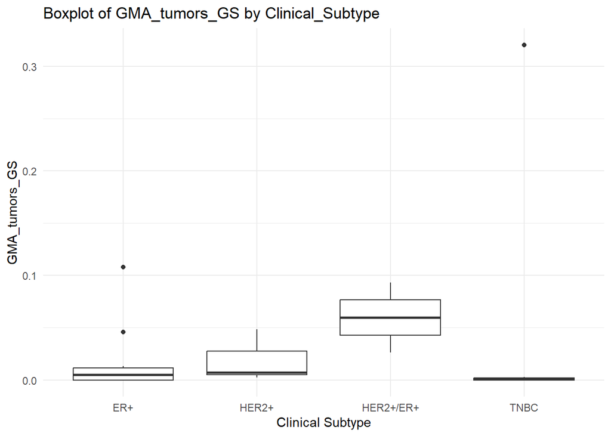

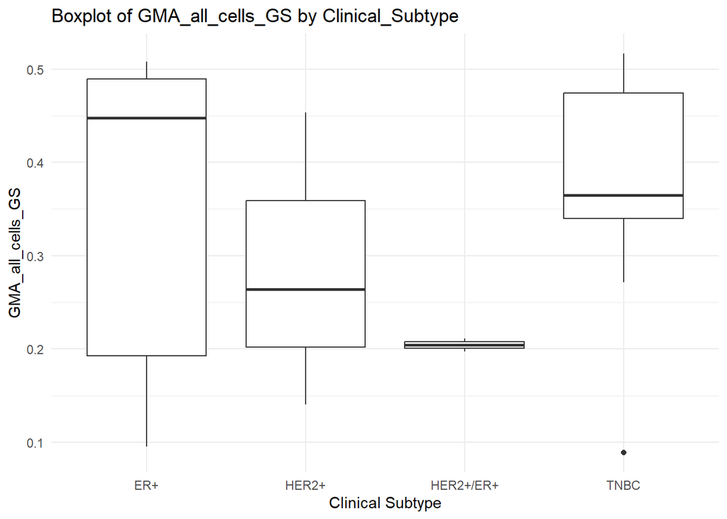

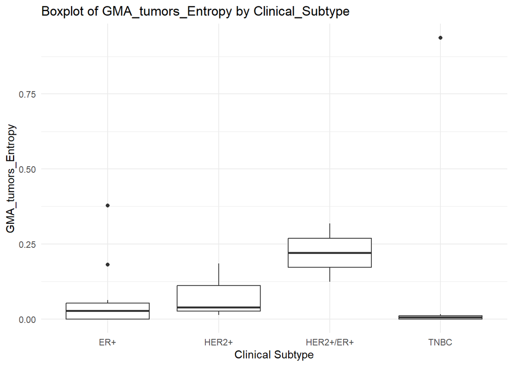

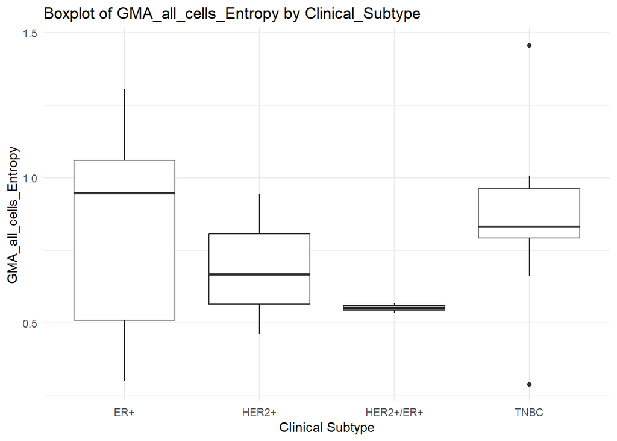

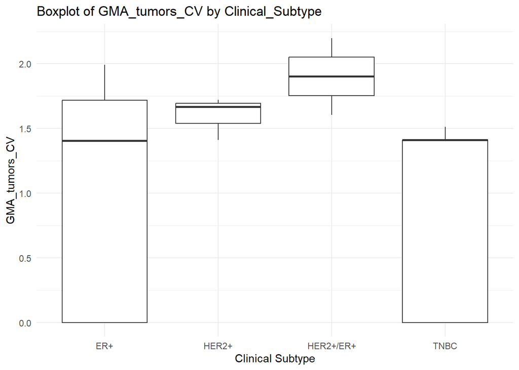

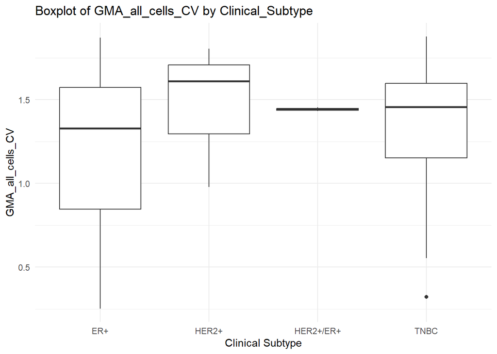

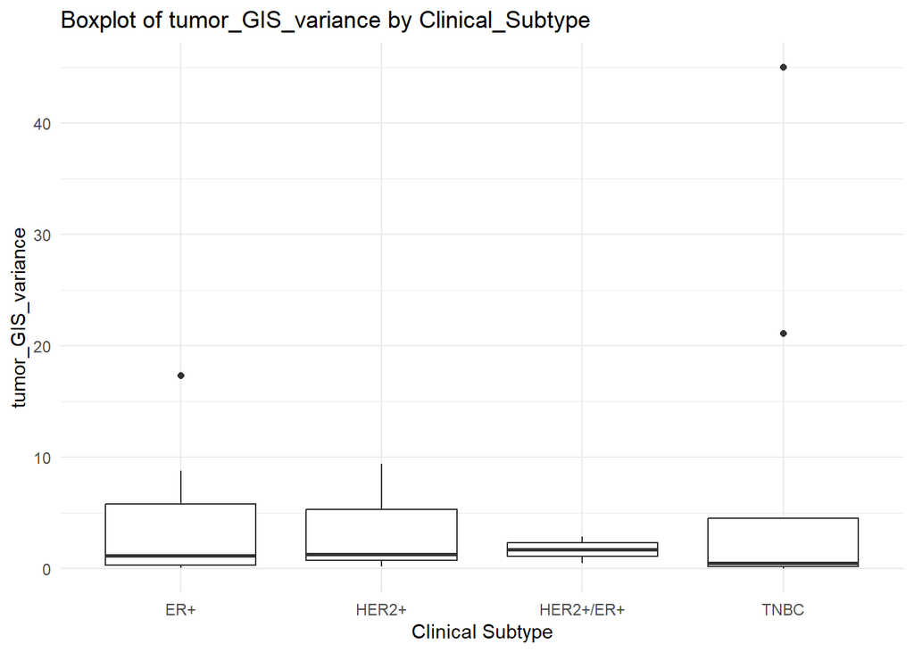

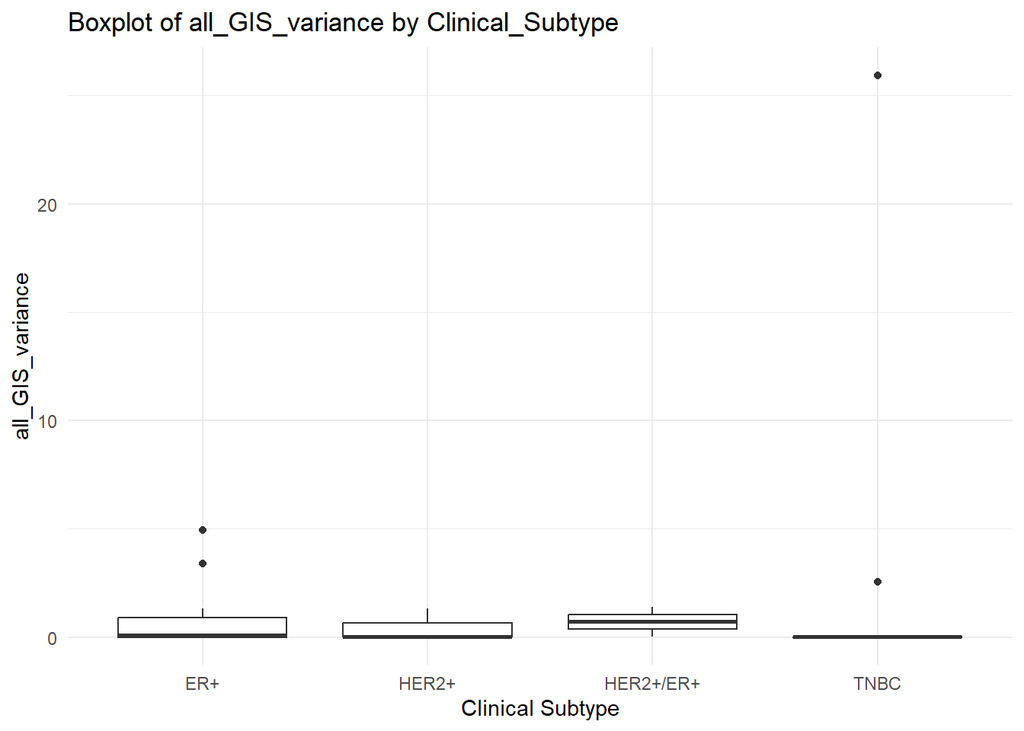

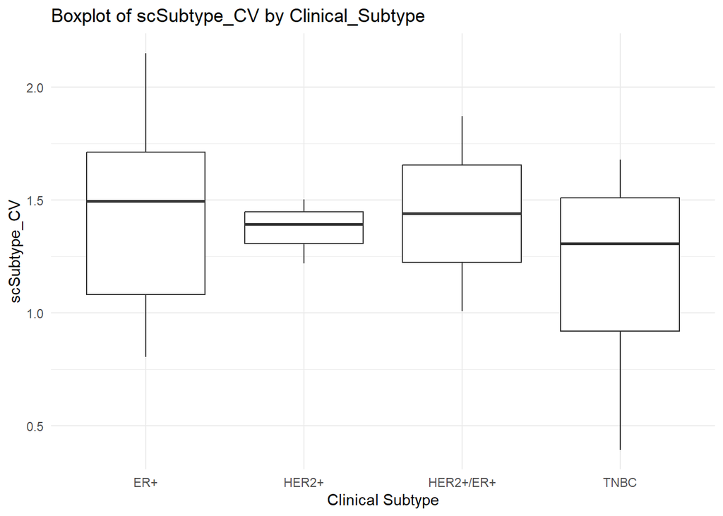

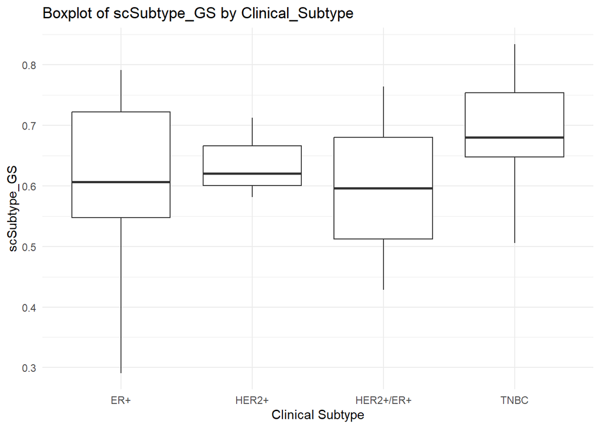

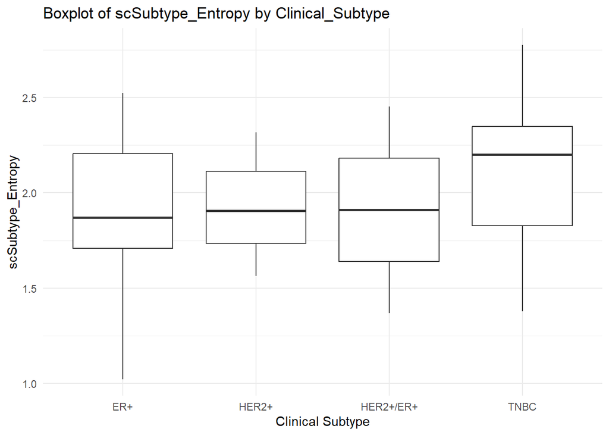

```r
library(ggplot2)

# Create a boxplot for each continuous variable based on Clinical_Subtype
for (col in continuous_columns) {
  p <- ggplot(merged_metadata, aes_string(x = "Clinical_Subtype", y = col)) +
    geom_boxplot() +
    theme_minimal() +
    labs(title = paste("Boxplot of", col, "by Clinical_Subtype"),
         x = "Clinical Subtype",
         y = col)
  print(p)
}
```

From the result, it seems that clinical sub type has no significant difference among each other on most of the variables. Except for those metrics on gene module analysis (GMA). Both the intra-tumor and all cells heterogeneity seems to account for some sub type difference.

# Model Fitting

## Models based on Gini-Simpson Index

### Linear model based on Gini-Simpson Index

Let’s start with a linear model and see the p-value to see whether some variables might be significant.

```r
# Read the merged_GS.csv file
merged_GS <- read.csv("merged_GS.csv")

# Remove 'Gender' from the data
merged_GS$Gender <- NULL

# Convert Clinical_Subtype to a factor and then to a numeric variable
merged_GS$Clinical_Subtype <- as.factor(merged_GS$Clinical_Subtype)
merged_GS$Clinical_Subtype <- as.numeric(merged_GS$Clinical_Subtype)

# Fit the linear model
GS_linear_model <- lm(Clinical_Subtype ~ . - Patient_ID, data = merged_GS)

# Summarize the model
GS_model_summary <- summary(GS_linear_model)
GS_model_summary
```

```
##
## Call:
## lm(formula = Clinical_Subtype ~ . - Patient_ID, data = merged_GS)
##
## Residuals:
##    Min     1Q Median     3Q    Max
## -1.784 -1.075 -0.116  1.072  2.235
##
## Coefficients:
##                    Estimate Std. Error t value Pr(>|t|)
## (Intercept)         0.21119    1.41695   0.149   0.8830
## GMA_tumors_GS       2.71523    4.29851   0.632   0.5348
## GMA_all_cells_GS   -2.86871    2.19992  -1.304   0.2070
## tumor_GIS_variance  0.04673    0.03230   1.447   0.1635
## all_GIS_variance    0.04067    0.05776   0.704   0.4895
## scSubtype_GS        4.24318    2.37957   1.783   0.0897 .
## ---
## Signif. codes:  0 '***' 0.001 '**' 0.01 '*' 0.05 '.' 0.1 ' ' 1
##
## Residual standard error: 1.352 on 20 degrees of freedom
## Multiple R-squared:  0.2311, Adjusted R-squared:  0.03884
## F-statistic: 1.202 on 5 and 20 DF,  p-value: 0.3439
```

Based on the p-value, it seems that none of the variable is significant.

### LASSO based on Gini-Simpson Index

Before fitting logistic model, we can try a linear model to see which variables might have a significant effect on the model and do some feature selection

```r
# Load required libraries
library(glmnet)
# Read the merged_GS.csv file
merged_GS <- read.csv("merged_GS.csv")

# Remove 'Gender' from the data
merged_GS$Gender <- NULL

# Convert Clinical_Subtype to a factor and then to a numeric variable
merged_GS$Clinical_Subtype <- as.factor(merged_GS$Clinical_Subtype)
merged_GS$Clinical_Subtype <- as.numeric(merged_GS$Clinical_Subtype)

# Prepare the data for glmnet
predictor_matrix <- model.matrix(Clinical_Subtype ~ . - Patient_ID, data = merged_GS)
response_vector <- merged_GS$Clinical_Subtype

# Fit the LASSO linear model
lambda_seq <- 10^seq(10, -2, length.out = 100) # Define a sequence of lambda values
lasso_model <- glmnet(predictor_matrix, response_vector, alpha = 1, lambda = lambda_seq)

# Cross-validation for choosing the best lambda
cv_lasso <- cv.glmnet(predictor_matrix, response_vector, alpha = 1, lambda = lambda_seq)
best_lambda <- cv_lasso$lambda.min

# Fit the final model with the best lambda
GS_lasso_model <- glmnet(predictor_matrix, response_vector, alpha = 1, lambda = best_lambda)

# Display the coefficients for the selected variables
coef(GS_lasso_model)
```

```
## 7 x 1 sparse Matrix of class "dgCMatrix"
##                          s0
## (Intercept)        2.307692
## (Intercept)        0.000000
## GMA_tumors_GS      .
## GMA_all_cells_GS   .
## tumor_GIS_variance .
## all_GIS_variance   .
## scSubtype_GS       .
```

### Multinomial Logistic Regression based on Gini-Simpson Index

Let’s first fit a multinomial logistic regression model based on the Gini-Simpson index:

```r
# Load required libraries
library(nnet)

# Read the merged_GS.csv file
merged_GS <- read.csv("merged_GS.csv")

# Remove 'Gender' from the data
merged_GS$Gender <- NULL

# Fit the multinomial logistic regression model
GSmodel <- multinom(Clinical_Subtype ~ . - Patient_ID, data = merged_GS)
# Display the model summary (output will be saved to the text file)
summary(GSmodel)
```

```
## Call:
## multinom(formula = Clinical_Subtype ~ . - Patient_ID, data = merged_GS)
##
## Coefficients:
##           (Intercept) GMA_tumors_GS GMA_all_cells_GS tumor_GIS_variance
## HER2+       -2.693535    -0.3073507        -6.184625         0.04399922
## HER2+/ER+    1.216288    36.9381474       -22.530254        -0.95161019
## TNBC        -5.821077     2.8777300        -5.496968         0.09686601
##           all_GIS_variance scSubtype_GS
## HER2+          -0.09996288     5.164866
## HER2+/ER+       1.02452447     3.340304
## TNBC            0.06735253    10.330370
##
## Std. Errors:
##           (Intercept) GMA_tumors_GS GMA_all_cells_GS tumor_GIS_variance
## HER2+        3.465561     15.207050         6.015147         0.09578252
## HER2+/ER+    5.604714     36.723772        17.004030         1.94398312
## TNBC         3.779649      8.558173         4.814154         0.06503088
##           all_GIS_variance scSubtype_GS
## HER2+            0.5388733     6.126725
## HER2+/ER+        1.6534768     9.310307
## TNBC             0.1366806     6.056712
##
## Residual Deviance: 47.8951
## AIC: 83.8951
```

Do a model selection based on the AIC criterion using a step-wise search method

```r
GSmodeli = step(GSmodel)
```

```
## Start:  AIC=83.9
## Clinical_Subtype ~ (Patient_ID + GMA_tumors_GS + GMA_all_cells_GS +
##     tumor_GIS_variance + all_GIS_variance + scSubtype_GS) - Patient_ID
##
## trying - GMA_tumors_GS
## trying - GMA_all_cells_GS
## trying - tumor_GIS_variance
## trying - all_GIS_variance
## trying - scSubtype_GS
##                      Df      AIC
## - all_GIS_variance   15 79.35368
## - GMA_tumors_GS      15 80.83432
## - scSubtype_GS       15 82.14586
## - tumor_GIS_variance 15 82.16164
## - GMA_all_cells_GS   15 83.13866
## <none>               18 83.89510
##
## Step:  AIC=79.35
## Clinical_Subtype ~ GMA_tumors_GS + GMA_all_cells_GS + tumor_GIS_variance +
##     scSubtype_GS
##
## trying - GMA_tumors_GS
## trying - GMA_all_cells_GS
## trying - tumor_GIS_variance
## trying - scSubtype_GS
##                      Df      AIC
## - GMA_tumors_GS      12 75.45792
## - tumor_GIS_variance 12 77.57429
## - GMA_all_cells_GS   12 77.78294
## - scSubtype_GS       12 78.02402
## <none>               15 79.35368
##
## Step:  AIC=75.46
## Clinical_Subtype ~ GMA_all_cells_GS + tumor_GIS_variance + scSubtype_GS
##
## trying - GMA_all_cells_GS
## trying - tumor_GIS_variance
## trying - scSubtype_GS
##                      Df      AIC
## - GMA_all_cells_GS    9 72.96092
```

[output cut: 9 more lines]

```
##                      Df      AIC
## - tumor_GIS_variance  6 70.03198
## - scSubtype_GS        6 71.21513
## <none>                9 72.96092
##
## Step:  AIC=70.03
## Clinical_Subtype ~ scSubtype_GS
##
## trying - scSubtype_GS
##                Df      AIC
## - scSubtype_GS  3 66.86896
## <none>          6 70.03198
##
## Step:  AIC=66.87
## Clinical_Subtype ~ 1
```

```r
summary(GSmodeli)
```

```
## Call:
## multinom(formula = Clinical_Subtype ~ 1, data = merged_GS)
##
## Coefficients:
##           (Intercept)
## HER2+      -1.3862408
## HER2+/ER+  -1.7916639
## TNBC       -0.2876066
##
## Std. Errors:
##           (Intercept)
## HER2+       0.6454962
## HER2+/ER+   0.7637465
## TNBC        0.4409578
##
## Residual Deviance: 60.86896
## AIC: 66.86896
```

Based on the result of step-wise search, it seems that none of the predictors above can provide a significant improvement on the null model based on the AIC criteria. But this is probably due to the lack of samples. We’ll process more data in the future to exam the result again.

### Cross-validation to validate the multinomial logistic model

```r
library(caret)
# Read the merged_GS.csv file
merged_GS <- read.csv("merged_GS.csv")

# Remove 'Gender' and 'Patient_ID' from the data
merged_GS$Gender <- NULL
merged_GS$Patient_ID <- NULL

# Convert 'Clinical_Subtype' to a factor
merged_GS$Clinical_Subtype <- as.factor(merged_GS$Clinical_Subtype)

# Create a matrix of predictor variables
predictors <- model.matrix(Clinical_Subtype ~ ., data = merged_GS)

# Set up cross-validation using the 'caret' package
cv_folds <- createFolds(merged_GS$Clinical_Subtype, k = 10)

# Perform k-fold cross-validation
cv_results <- lapply(cv_folds, function(fold_index) {
  # Split data into training and testing sets
  train_data <- merged_GS[-fold_index, ]
  test_data <- merged_GS[fold_index, ]

  # Fit the multinomial logistic regression model on training data
  GSmodel <- multinom(Clinical_Subtype ~ ., data = train_data)

  # Make predictions on the test set
  predicted <- predict(GSmodel, newdata = test_data)

  # Calculate accuracy
  accuracy <- mean(predicted == test_data$Clinical_Subtype)

  return(accuracy)
})
# Calculate the mean accuracy across all folds
mean_accuracy <- mean(unlist(cv_results))

# Display the mean accuracy
mean_accuracy
```

```
## [1] 0.4083333
```

```r
# Load required libraries
library(nnet)
library(caret)

# Read the merged_GS.csv file
merged_GS <- read.csv("merged_GS.csv")

# Remove 'Gender' and 'Patient_ID' from the data
merged_GS$Gender <- NULL
merged_GS$Patient_ID <- NULL

# Convert 'Clinical_Subtype' to a factor
merged_GS$Clinical_Subtype <- as.factor(merged_GS$Clinical_Subtype)

# Set up cross-validation using the 'caret' package
cv_folds <- createFolds(merged_GS$Clinical_Subtype, k = 10)

# Perform k-fold cross-validation
cv_results_null <- lapply(cv_folds, function(fold_index) {
  # Split data into training and testing sets
  train_data <- merged_GS[-fold_index, ]
  test_data <- merged_GS[fold_index, ]

  # Fit the null model (intercept-only model) on training data
  null_model <- multinom(Clinical_Subtype ~ 1, data = train_data)

  # Make predictions on the test set
  predicted_null <- predict(null_model, newdata = test_data)

  # Calculate accuracy
  accuracy_null <- mean(predicted_null == test_data$Clinical_Subtype)

  return(accuracy_null)
})
# Calculate the mean accuracy for the null model across all folds
mean_accuracy_null <- mean(unlist(cv_results_null))

# Display the mean accuracy of the null model
mean_accuracy_null
```

```
## [1] 0.5
```

### SVM with Radial Kernrl and Cross-validation

```r
# Load required libraries
library(e1071)
library(caret)
set.seed(42)

# Read the merged_GS.csv file
merged_GS <- read.csv("merged_GS.csv")

# Remove 'Gender' and 'Patient_ID' from the data
merged_GS$Gender <- NULL
merged_GS$Patient_ID <- NULL

# Convert 'Clinical_Subtype' to a factor
merged_GS$Clinical_Subtype <- as.factor(merged_GS$Clinical_Subtype)

# Set up cross-validation using the 'caret' package
cv_folds <- createFolds(merged_GS$Clinical_Subtype, k = 10)

# Perform k-fold cross-validation
cv_results_svm <- lapply(cv_folds, function(fold_index) {
  # Split data into training and testing sets
  train_data <- merged_GS[-fold_index, ]
  test_data <- merged_GS[fold_index, ]

  # Fit the SVM model on training data
  svm_model <- svm(Clinical_Subtype ~ ., data = train_data, kernel = "radial")

  # Make predictions on the test set
  predicted_svm <- predict(svm_model, newdata = test_data)

  # Calculate accuracy
  accuracy_svm <- mean(predicted_svm == test_data$Clinical_Subtype)

  return(accuracy_svm)
})

# Calculate the mean accuracy for the SVM model across all folds
mean_accuracy_svm <- mean(unlist(cv_results_svm))

# Display the mean accuracy of the SVM model
mean_accuracy_svm
```

```
## [1] 0.4333333
```

The accuracy is 0.433, which is still close to the intercept-only model but still lower.

### Random Forest Model and Out-of-bag validation

```r
# Load required library
library(randomForest)
# Read the merged_GS.csv file
merged_GS <- read.csv("merged_GS.csv")

# Remove 'Gender' from the data
merged_GS$Gender <- NULL

# Convert 'Clinical_Subtype' to a factor
merged_GS$Clinical_Subtype <- as.factor(merged_GS$Clinical_Subtype)

# Fit the random forest model
rf_model <- randomForest(Clinical_Subtype ~ . - Patient_ID, data = merged_GS, importance = TRUE, proximity = TRUE)

# Display OOB error rate
print(rf_model)
```

```
##
## Call:
##  randomForest(formula = Clinical_Subtype ~ . - Patient_ID, data = merged_GS,      importance = TRUE, proximity = TRUE)
##                Type of random forest: classification
##                      Number of trees: 500
## No. of variables tried at each split: 2
##
##         OOB estimate of  error rate: 73.08%
## Confusion matrix:
##           ER+ HER2+ HER2+/ER+ TNBC class.error
## ER+         4     0         1    7   0.6666667
## HER2+       2     0         0    1   1.0000000
## HER2+/ER+   2     0         0    0   1.0000000
## TNBC        6     0         0    3   0.6666667
```

```r
# Display feature importance
importance(rf_model)
```

```
##                          ER+      HER2+  HER2+/ER+       TNBC
## GMA_tumors_GS      -4.618756 -1.7372705  1.2669398  6.5343115
## GMA_all_cells_GS   -2.732814 -0.6669632  2.6644683  1.6150836
## tumor_GIS_variance -4.973614 -3.6152147 -2.3461417 -2.0015374
## all_GIS_variance   -4.774092  0.1796111 -0.8170415 -1.7829728
## scSubtype_GS        1.113957 -2.8633796 -3.6533577  0.9426657
##                    MeanDecreaseAccuracy MeanDecreaseGini
## GMA_tumors_GS                0.58974461         3.966454
## GMA_all_cells_GS            -1.21128896         3.305061
## tumor_GIS_variance          -5.74197129         2.896490
## all_GIS_variance            -4.60543445         2.521769
## scSubtype_GS                 0.02369464         3.578712
```

The out-of-pocket error rate is 73.08%, which makes this model the least accurate so far.

### Discussion

The result turns out that none of our predictors are significant and the result is even worse than a intercept-only model is largely because of the lack of samples and our unbalanced dataset. In the future, we’ll collect more data and try whether the intra-tumor heterogeneity can be used to predict cancer type.

## Models based on Entropy

Below we’ll try some other metrics for intra-tumor heterogeneity but since the Entropy and Gini-Simpson Index has some correlation, we won’t fit linear models or LASSO to interpret the relation between the response variable and features.

### Multinomial Logistic Regression Based on Entropy

```r
# Load required libraries
library(nnet)

# Read the merged_Entropy.csv file
merged_Entropy <- read.csv("merged_Entropy.csv")

# Remove 'Gender' from the data
merged_Entropy$Gender <- NULL

# Fit the multinomial logistic regression model
Emodel <- multinom(Clinical_Subtype ~ . - Patient_ID, data = merged_Entropy)
# Display the model summary (output will be saved to the text file)
summary(Emodel)
```

```
## Call:
## multinom(formula = Clinical_Subtype ~ . - Patient_ID, data = merged_Entropy)
##
## Coefficients:
##           (Intercept) GMA_tumors_Entropy GMA_all_cells_Entropy
## HER2+       -1.468717           1.333215             -2.862250
## HER2+/ER+   -7.123392          63.101381            -60.725433
## TNBC        -3.820442           1.450808             -2.520064
##           tumor_GIS_variance all_GIS_variance scSubtype_Entropy
## HER2+             0.03183721      -0.12718238          1.107627
## HER2+/ER+        -0.83092750       2.02284601         14.349693
## TNBC              0.08627092       0.04518779          2.436592
##
## Std. Errors:
##           (Intercept) GMA_tumors_Entropy GMA_all_cells_Entropy
## HER2+        3.144720           4.532760              3.089875
## HER2+/ER+    4.629239           4.701189              4.109066
## TNBC         3.006202           2.977389              2.440871
##           tumor_GIS_variance all_GIS_variance scSubtype_Entropy
## HER2+             0.09675556        0.5641000          1.927294
## HER2+/ER+         1.58260616        1.2257021          2.749397
## TNBC              0.06207364        0.1268877          1.660446
##
## Residual Deviance: 47.15937
## AIC: 83.15937
```

```r
Emodeli = step(Emodel)
```

```
## Start:  AIC=83.16
## Clinical_Subtype ~ (Patient_ID + GMA_tumors_Entropy + GMA_all_cells_Entropy +
##     tumor_GIS_variance + all_GIS_variance + scSubtype_Entropy) -
##     Patient_ID
##
## trying - GMA_tumors_Entropy
## trying - GMA_all_cells_Entropy
## trying - tumor_GIS_variance
## trying - all_GIS_variance
## trying - scSubtype_Entropy
##                         Df      AIC
## - all_GIS_variance      15 79.00139
## - scSubtype_Entropy     15 81.10351
## - tumor_GIS_variance    15 81.46667
## <none>                  18 83.15937
## - GMA_tumors_Entropy    15 83.18408
## - GMA_all_cells_Entropy 15 84.46687
##
## Step:  AIC=79
## Clinical_Subtype ~ GMA_tumors_Entropy + GMA_all_cells_Entropy +
##     tumor_GIS_variance + scSubtype_Entropy
##
## trying - GMA_tumors_Entropy
## trying - GMA_all_cells_Entropy
## trying - tumor_GIS_variance
## trying - scSubtype_Entropy
##                         Df      AIC
## - scSubtype_Entropy     12 76.81018
## - tumor_GIS_variance    12 77.02004
## - GMA_tumors_Entropy    12 77.54980
## <none>                  15 79.00139
## - GMA_all_cells_Entropy 12 79.06986
##
## Step:  AIC=76.81
## Clinical_Subtype ~ GMA_tumors_Entropy + GMA_all_cells_Entropy +
##     tumor_GIS_variance
##
## trying - GMA_tumors_Entropy
## trying - GMA_all_cells_Entropy
## trying - tumor_GIS_variance
```

[output cut: 11 more lines]

```
##                         Df      AIC
## - GMA_tumors_Entropy     6 70.34649
## - GMA_all_cells_Entropy  6 71.92996
## <none>                   9 73.17829
##
## Step:  AIC=70.35
## Clinical_Subtype ~ GMA_all_cells_Entropy
##
## trying - GMA_all_cells_Entropy
##                         Df      AIC
## - GMA_all_cells_Entropy  3 66.86896
## <none>                   6 70.34649
##
## Step:  AIC=66.87
## Clinical_Subtype ~ 1
```

```r
summary(Emodeli)
```

```
## Call:
## multinom(formula = Clinical_Subtype ~ 1, data = merged_Entropy)
##
## Coefficients:
##           (Intercept)
## HER2+      -1.3862408
## HER2+/ER+  -1.7916639
## TNBC       -0.2876066
##
## Std. Errors:
##           (Intercept)
## HER2+       0.6454962
## HER2+/ER+   0.7637465
## TNBC        0.4409578
##
## Residual Deviance: 60.86896
## AIC: 66.86896
```

It seems that Entropy as a metric for intra-tumor heterogeneity also doesn’t work well for multinomial logistic regression model.

#### Cross-validation for Multinomial Logistic Model

```r
library(caret)

# Read the merged_Entropy.csv file
merged_Entropy <- read.csv("merged_Entropy.csv")

# Remove 'Gender' and 'Patient_ID' from the data
merged_Entropy$Gender <- NULL
merged_Entropy$Patient_ID <- NULL

# Convert 'Clinical_Subtype' to a factor
merged_Entropy$Clinical_Subtype <- as.factor(merged_Entropy$Clinical_Subtype)

# Create a matrix of predictor variables
predictors <- model.matrix(Clinical_Subtype ~ ., data = merged_Entropy)

# Set up cross-validation using the 'caret' package
cv_folds <- createFolds(merged_Entropy$Clinical_Subtype, k = 10)

# Perform k-fold cross-validation
cv_results <- lapply(cv_folds, function(fold_index) {
  # Split data into training and testing sets
  train_data <- merged_Entropy[-fold_index, ]
  test_data <- merged_Entropy[fold_index, ]

  # Fit the multinomial logistic regression model on training data
  Entropymodel <- multinom(Clinical_Subtype ~ ., data = train_data)

  # Make predictions on the test set
  predicted <- predict(Entropymodel, newdata = test_data)

  # Calculate accuracy
  accuracy <- mean(predicted == test_data$Clinical_Subtype)

  return(accuracy)
})
# Calculate the mean accuracy across all folds
mean_accuracy <- mean(unlist(cv_results))

# Display the mean accuracy
mean_accuracy
```

```
## [1] 0.2583333
```

### SVM

```r
# Load required libraries
library(e1071)
library(caret)

set.seed(42)

# Read the merged_Entropy.csv file
merged_Entropy <- read.csv("merged_Entropy.csv")

# Remove 'Gender' and 'Patient_ID' from the data
merged_Entropy$Gender <- NULL
merged_Entropy$Patient_ID <- NULL

# Convert 'Clinical_Subtype' to a factor
merged_Entropy$Clinical_Subtype <- as.factor(merged_Entropy$Clinical_Subtype)

# Set up cross-validation using the 'caret' package
cv_folds <- createFolds(merged_Entropy$Clinical_Subtype, k = 10)

# Perform k-fold cross-validation
cv_results_svm <- lapply(cv_folds, function(fold_index) {
  # Split data into training and testing sets
  train_data <- merged_Entropy[-fold_index, ]
  test_data <- merged_Entropy[fold_index, ]

  # Fit the SVM model on training data
  svm_model <- svm(Clinical_Subtype ~ ., data = train_data, kernel = "radial")

  # Make predictions on the test set
  predicted_svm <- predict(svm_model, newdata = test_data)

  # Calculate accuracy
  accuracy_svm <- mean(predicted_svm == test_data$Clinical_Subtype)

  return(accuracy_svm)
})

# Calculate the mean accuracy for the SVM model across all folds
mean_accuracy_svm <- mean(unlist(cv_results_svm))

# Display the mean accuracy of the SVM model
mean_accuracy_svm
```

```
## [1] 0.4833333
```

### Random Forest

```r
# Load required library
library(randomForest)

# Read the merged_Entropy.csv file
merged_Entropy <- read.csv("merged_Entropy.csv")

# Remove 'Gender' from the data
merged_Entropy$Gender <- NULL

# Convert 'Clinical_Subtype' to a factor
merged_Entropy$Clinical_Subtype <- as.factor(merged_Entropy$Clinical_Subtype)

# Fit the random forest model
rf_model <- randomForest(Clinical_Subtype ~ . - Patient_ID, data = merged_Entropy, importance = TRUE, proximity = TRUE)

# Display OOB error rate
print(rf_model)
```

```
##
## Call:
##  randomForest(formula = Clinical_Subtype ~ . - Patient_ID, data = merged_Entropy,      importance = TRUE, proximity = TRUE)
##                Type of random forest: classification
##                      Number of trees: 500
## No. of variables tried at each split: 2
##
##         OOB estimate of  error rate: 73.08%
## Confusion matrix:
##           ER+ HER2+ HER2+/ER+ TNBC class.error
## ER+         4     0         1    7   0.6666667
## HER2+       2     0         0    1   1.0000000
## HER2+/ER+   2     0         0    0   1.0000000
## TNBC        6     0         0    3   0.6666667
```

```r
# Display feature importance
importance(rf_model)
```

```
##                             ER+      HER2+  HER2+/ER+      TNBC
## GMA_tumors_Entropy    -6.628014 -1.5851066  1.4170505  5.417854
## GMA_all_cells_Entropy -3.479886 -0.6549344  2.5461701  2.109274
## tumor_GIS_variance    -5.769147 -3.5837665 -0.6327087 -2.360435
## all_GIS_variance      -5.384671 -1.1485910 -2.0080483 -1.353737
## scSubtype_Entropy     -3.696348 -2.7425777 -4.1950380 -2.152938
##                       MeanDecreaseAccuracy MeanDecreaseGini
## GMA_tumors_Entropy              -1.7948449         3.771864
## GMA_all_cells_Entropy           -0.6090802         3.710818
## tumor_GIS_variance              -5.6652238         2.709683
## all_GIS_variance                -5.6023758         2.608625
## scSubtype_Entropy               -5.0474489         3.408651
```

The error rate for this model is identical to the random forest model fitted using Gini-Simpson index as metric.

## Model based on CV

At last, we see whether CV, which is usually used to measure the variance of continuous data can provide better insights.

### Multinomial logistic model

```r
# Load required libraries
library(nnet)

# Read the merged_CV.csv file
merged_CV <- read.csv("merged_CV.csv")

# Remove 'Gender' from the data
merged_CV$Gender <- NULL

# Fit the multinomial logistic regression model
CVmodel <- multinom(Clinical_Subtype ~ . - Patient_ID, data = merged_CV)
# Display the model summary (output will be saved to the text file)
summary(CVmodel)
```

```
## Call:
## multinom(formula = Clinical_Subtype ~ . - Patient_ID, data = merged_CV)
##
## Coefficients:
##           (Intercept) GMA_tumors_CV GMA_all_cells_CV tumor_GIS_variance
## HER2+       -5.586508     2.0247850         1.155639         0.09507111
## HER2+/ER+  -30.085329    10.2536595         3.249920         0.03059934
## TNBC         1.649298    -0.9549718         1.764906         0.07275755
##           all_GIS_variance scSubtype_CV
## HER2+           -0.1459014   -0.3363284
## HER2+/ER+        0.1964129    4.0472888
## TNBC             0.1330918   -2.9450587
##
## Std. Errors:
##           (Intercept) GMA_tumors_CV GMA_all_cells_CV tumor_GIS_variance
## HER2+        5.685539     2.3940521         2.014688         0.12546908
## HER2+/ER+   26.480969     7.3399513         6.178133         0.44692197
## TNBC         2.636587     0.8073338         1.328786         0.06097104
##           all_GIS_variance scSubtype_CV
## HER2+            0.6847281     1.848330
## HER2+/ER+        0.4735158     5.279962
## TNBC             0.1796118     1.690884
##
## Residual Deviance: 43.41023
## AIC: 79.41023
```

```r
CVmodeli = step(CVmodel)
```

```
## Start:  AIC=79.41
## Clinical_Subtype ~ (Patient_ID + GMA_tumors_CV + GMA_all_cells_CV +
##     tumor_GIS_variance + all_GIS_variance + scSubtype_CV) - Patient_ID
##
## trying - GMA_tumors_CV
## trying - GMA_all_cells_CV
## trying - tumor_GIS_variance
## trying - all_GIS_variance
## trying - scSubtype_CV
##                      Df      AIC
## - all_GIS_variance   15 75.21343
## - tumor_GIS_variance 15 75.28504
## - GMA_all_cells_CV   15 75.94072
## - scSubtype_CV       15 79.22443
## <none>               18 79.41023
## - GMA_tumors_CV      15 82.94546
##
## Step:  AIC=75.21
## Clinical_Subtype ~ GMA_tumors_CV + GMA_all_cells_CV + tumor_GIS_variance +
##     scSubtype_CV
##
## trying - GMA_tumors_CV
## trying - GMA_all_cells_CV
## trying - tumor_GIS_variance
## trying - scSubtype_CV
##                      Df      AIC
## - GMA_all_cells_CV   12 71.57359
## - tumor_GIS_variance 12 71.81374
## - scSubtype_CV       12 74.64643
## <none>               15 75.21343
## - GMA_tumors_CV      12 77.71446
##
## Step:  AIC=71.57
## Clinical_Subtype ~ GMA_tumors_CV + tumor_GIS_variance + scSubtype_CV
##
## trying - GMA_tumors_CV
## trying - tumor_GIS_variance
## trying - scSubtype_CV
##                      Df      AIC
## - tumor_GIS_variance  9 66.87635
## - scSubtype_CV        9 70.07173
## <none>               12 71.57359
## - GMA_tumors_CV       9 73.68843
##
## Step:  AIC=66.88
## Clinical_Subtype ~ GMA_tumors_CV + scSubtype_CV
##
## trying - GMA_tumors_CV
## trying - scSubtype_CV
##                 Df      AIC
## - scSubtype_CV   6 64.81073
## <none>           9 66.87635
## - GMA_tumors_CV  6 70.21875
##
## Step:  AIC=64.81
## Clinical_Subtype ~ GMA_tumors_CV
##
## trying - GMA_tumors_CV
##                 Df      AIC
## <none>           6 64.81073
## - GMA_tumors_CV  3 66.86896
```

```r
summary(CVmodeli)
```

```
## Call:
## multinom(formula = Clinical_Subtype ~ GMA_tumors_CV, data = merged_CV)
##
## Coefficients:
##           (Intercept) GMA_tumors_CV
## HER2+      -3.9519803     1.8126257
## HER2+/ER+ -11.7791322     6.0324830
## TNBC        0.2012583    -0.5147686
##
## Std. Errors:
##           (Intercept) GMA_tumors_CV
## HER2+       3.0663383     1.9103211
## HER2+/ER+   6.6225071     3.6442054
## TNBC        0.7063816     0.5826816
##
## Residual Deviance: 52.81073
## AIC: 64.81073
```

It seems that when using CV, GMA_tumors_CV might be a good predictor.

Let’s see what’s it’s p-value for a linear model:

```r
# Read the merged_CV.csv file
merged_CV <- read.csv("merged_CV.csv")

# Remove 'Gender' from the data
merged_CV$Gender <- NULL

# Convert Clinical_Subtype to a factor and then to a numeric variable
merged_CV$Clinical_Subtype <- as.factor(merged_CV$Clinical_Subtype)
merged_CV$Clinical_Subtype <- as.numeric(merged_CV$Clinical_Subtype)

# Fit the linear model
CV_linear_model <- lm(Clinical_Subtype ~ . - Patient_ID, data = merged_CV)

# Summarize the model
CV_model_summary <- summary(CV_linear_model)
CV_model_summary
```

```
##
## Call:
## lm(formula = Clinical_Subtype ~ . - Patient_ID, data = merged_CV)
##
## Residuals:
##     Min      1Q  Median      3Q     Max
## -1.8904 -1.0956 -0.1155  0.9305  2.3049
##
## Coefficients:
##                    Estimate Std. Error t value Pr(>|t|)
## (Intercept)         2.96599    1.25997   2.354   0.0289 *
## GMA_tumors_CV      -0.29381    0.37263  -0.788   0.4397
## GMA_all_cells_CV    0.76868    0.63207   1.216   0.2381
## tumor_GIS_variance  0.03643    0.03372   1.080   0.2928
## all_GIS_variance    0.04868    0.05665   0.859   0.4004
## scSubtype_CV       -1.16871    0.66715  -1.752   0.0951 .
## ---
## Signif. codes:  0 '***' 0.001 '**' 0.01 '*' 0.05 '.' 0.1 ' ' 1
##
## Residual standard error: 1.348 on 20 degrees of freedom
## Multiple R-squared:  0.2353, Adjusted R-squared:  0.04413
## F-statistic: 1.231 on 5 and 20 DF,  p-value: 0.3315
```

#### Cross-validation on GMA_tumors_CV

```r
library(caret)

# Read the merged_CV.csv file
merged_CV <- read.csv("merged_CV.csv")

# Remove 'Gender' and 'Patient_ID' from the data
merged_CV$Gender <- NULL
merged_CV$Patient_ID <- NULL

# Convert 'Clinical_Subtype' to a factor
merged_CV$Clinical_Subtype <- as.factor(merged_CV$Clinical_Subtype)

# Create a matrix of predictor variables
predictors <- model.matrix(Clinical_Subtype ~ GMA_tumors_CV, data = merged_CV)

# Set up cross-validation using the 'caret' package
cv_folds <- createFolds(merged_CV$Clinical_Subtype, k = 10)

# Perform k-fold cross-validation
cv_results <- lapply(cv_folds, function(fold_index) {
  # Split data into training and testing sets
  train_data <- merged_CV[-fold_index, ]
  test_data <- merged_CV[fold_index, ]

  # Fit the multinomial logistic regression model on training data
  CVmodel <- multinom(Clinical_Subtype ~ ., data = train_data)

  # Make predictions on the test set
  predicted <- predict(CVmodel, newdata = test_data)

  # Calculate accuracy
  accuracy <- mean(predicted == test_data$Clinical_Subtype)

  return(accuracy)
})
# Calculate the mean accuracy across all folds
mean_accuracy <- mean(unlist(cv_results))

# Display the mean accuracy
mean_accuracy
```

```
## [1] 0.3916667
```

The accuracy is 0.3917, which is lower than the intercept-only model.

#### Cross-validation based on all the variables

```r
library(caret)

# Read the merged_CV.csv file
merged_CV <- read.csv("merged_CV.csv")

# Remove 'Gender' and 'Patient_ID' from the data
merged_CV$Gender <- NULL
merged_CV$Patient_ID <- NULL

# Convert 'Clinical_Subtype' to a factor
merged_CV$Clinical_Subtype <- as.factor(merged_CV$Clinical_Subtype)

# Create a matrix of predictor variables
predictors <- model.matrix(Clinical_Subtype ~ ., data = merged_CV)

# Set up cross-validation using the 'caret' package
cv_folds <- createFolds(merged_CV$Clinical_Subtype, k = 10)

# Perform k-fold cross-validation
cv_results <- lapply(cv_folds, function(fold_index) {
  # Split data into training and testing sets
  train_data <- merged_CV[-fold_index, ]
  test_data <- merged_CV[fold_index, ]

  # Fit the multinomial logistic regression model on training data
  CVmodel <- multinom(Clinical_Subtype ~ ., data = train_data)

  # Make predictions on the test set
  predicted <- predict(CVmodel, newdata = test_data)

  # Calculate accuracy
  accuracy <- mean(predicted == test_data$Clinical_Subtype)

  return(accuracy)
})
# Calculate the mean accuracy across all folds
mean_accuracy <- mean(unlist(cv_results))

# Display the mean accuracy
mean_accuracy
```

```
## [1] 0.25
```

### SVM based on GMA_tumor_CV

```r
# Load required libraries
library(e1071)
library(caret)

set.seed(42)

# Read the merged_CV.csv file
merged_CV <- read.csv("merged_CV.csv")

# Remove 'Gender' and 'Patient_ID' from the data
merged_CV$Gender <- NULL
merged_CV$Patient_ID <- NULL

# Convert 'Clinical_Subtype' to a factor
merged_CV$Clinical_Subtype <- as.factor(merged_CV$Clinical_Subtype)

# Set up cross-validation using the 'caret' package
cv_folds <- createFolds(merged_CV$Clinical_Subtype, k = 10)

# Perform k-fold cross-validation
cv_results_svm <- lapply(cv_folds, function(fold_index) {
  # Split data into training and testing sets
  train_data <- merged_CV[-fold_index, ]
  test_data <- merged_CV[fold_index, ]

  # Fit the SVM model on training data
  svm_model <- svm(Clinical_Subtype ~ GMA_tumors_CV, data = train_data, kernel = "radial")

  # Make predictions on the test set
  predicted_svm <- predict(svm_model, newdata = test_data)

  # Calculate accuracy
  accuracy_svm <- mean(predicted_svm == test_data$Clinical_Subtype)

  return(accuracy_svm)
})

# Calculate the mean accuracy for the SVM model across all folds
mean_accuracy_svm <- mean(unlist(cv_results_svm))

# Display the mean accuracy of the SVM model
mean_accuracy_svm
```

```
## [1] 0.45
```

This time, the model gives an accuracy of 0.45, which is quite close to the intercept-only model.

### SVM based on all variables

```r
# Load required libraries
library(e1071)
library(caret)

set.seed(42)

# Read the merged_CV.csv file
merged_CV <- read.csv("merged_CV.csv")

# Remove 'Gender' and 'Patient_ID' from the data
merged_CV$Gender <- NULL
merged_CV$Patient_ID <- NULL

# Convert 'Clinical_Subtype' to a factor
merged_CV$Clinical_Subtype <- as.factor(merged_CV$Clinical_Subtype)

# Set up cross-validation using the 'caret' package
cv_folds <- createFolds(merged_CV$Clinical_Subtype, k = 10)

# Perform k-fold cross-validation
cv_results_svm <- lapply(cv_folds, function(fold_index) {
  # Split data into training and testing sets
  train_data <- merged_CV[-fold_index, ]
  test_data <- merged_CV[fold_index, ]

  # Fit the SVM model on training data
  svm_model <- svm(Clinical_Subtype ~ ., data = train_data, kernel = "radial")

  # Make predictions on the test set
  predicted_svm <- predict(svm_model, newdata = test_data)

  # Calculate accuracy
  accuracy_svm <- mean(predicted_svm == test_data$Clinical_Subtype)

  return(accuracy_svm)
})

# Calculate the mean accuracy for the SVM model across all folds
mean_accuracy_svm <- mean(unlist(cv_results_svm))

# Display the mean accuracy of the SVM model
mean_accuracy_svm
```

```
## [1] 0.4666667
```

### Random Forest

```r
# Load required library
library(randomForest)

# Read the merged_Entropy.csv file
merged_Entropy <- read.csv("merged_Entropy.csv")

# Remove 'Gender' from the data
merged_Entropy$Gender <- NULL

# Convert 'Clinical_Subtype' to a factor
merged_Entropy$Clinical_Subtype <- as.factor(merged_Entropy$Clinical_Subtype)

# Fit the random forest model
rf_model <- randomForest(Clinical_Subtype ~ . - Patient_ID, data = merged_Entropy, importance = TRUE, proximity = TRUE)

# Display OOB error rate
print(rf_model)
```

```
##
## Call:
##  randomForest(formula = Clinical_Subtype ~ . - Patient_ID, data = merged_Entropy,      importance = TRUE, proximity = TRUE)
##                Type of random forest: classification
##                      Number of trees: 500
## No. of variables tried at each split: 2
##
##         OOB estimate of  error rate: 73.08%
## Confusion matrix:
##           ER+ HER2+ HER2+/ER+ TNBC class.error
## ER+         4     0         1    7   0.6666667
## HER2+       2     0         0    1   1.0000000
## HER2+/ER+   2     0         0    0   1.0000000
## TNBC        6     0         0    3   0.6666667
```

```r
# Display feature importance
importance(rf_model)
```

```
##                             ER+      HER2+  HER2+/ER+      TNBC
## GMA_tumors_Entropy    -6.628014 -1.5851066  1.4170505  5.417854
## GMA_all_cells_Entropy -3.479886 -0.6549344  2.5461701  2.109274
## tumor_GIS_variance    -5.769147 -3.5837665 -0.6327087 -2.360435
## all_GIS_variance      -5.384671 -1.1485910 -2.0080483 -1.353737
## scSubtype_Entropy     -3.696348 -2.7425777 -4.1950380 -2.152938
##                       MeanDecreaseAccuracy MeanDecreaseGini
## GMA_tumors_Entropy              -1.7948449         3.771864
## GMA_all_cells_Entropy           -0.6090802         3.710818
## tumor_GIS_variance              -5.6652238         2.709683
## all_GIS_variance                -5.6023758         2.608625
## scSubtype_Entropy               -5.0474489         3.408651
```

```r
# Load required library
library(randomForest)

# Read the merged_CV.csv file
merged_CV <- read.csv("merged_CV.csv")

# Remove 'Gender' from the data
merged_CV$Gender <- NULL

# Convert 'Clinical_Subtype' to a factor
merged_CV$Clinical_Subtype <- as.factor(merged_CV$Clinical_Subtype)

# Fit the random forest model
rf_model <- randomForest(Clinical_Subtype ~ GMA_tumors_CV, data = merged_CV, importance = TRUE, proximity = TRUE)

# Display OOB error rate
print(rf_model)
```

```
##
## Call:
##  randomForest(formula = Clinical_Subtype ~ GMA_tumors_CV, data = merged_CV,      importance = TRUE, proximity = TRUE)
##                Type of random forest: classification
##                      Number of trees: 500
## No. of variables tried at each split: 1
##
##         OOB estimate of  error rate: 76.92%
## Confusion matrix:
##           ER+ HER2+ HER2+/ER+ TNBC class.error
## ER+         4     3         0    5   0.6666667
## HER2+       2     0         0    1   1.0000000
## HER2+/ER+   1     1         0    0   1.0000000
## TNBC        4     2         1    2   0.7777778
```

```r
# Display feature importance
importance(rf_model)
```

```
##                    ER+     HER2+ HER2+/ER+     TNBC MeanDecreaseAccuracy
## GMA_tumors_CV 5.775193 -4.823399  -3.02737 11.74293             8.551188
##               MeanDecreaseGini
## GMA_tumors_CV         12.72309
```

## Discussion

However, as the sample is too small, with only 26 samples and extremely unbalanced, making our model even weaker than the intercept-only model. In the future, we’ll perform this analysis on other big data sets to gather training data and hopefully receives better accuracy and make the interpretability of models more powerful and convincing.